# Assignment 3

# Dataset Description: U.S. Bilateral Trade in Poultry Products

This dataset contains bilateral international trade data for the United States as the reporter country, focusing on the commodity classified under “**meat and edible offal**” of poultry, traded in fresh, chilled, or frozen form.

The dataset includes poultry products, covering common cuts and parts such as breasts, thighs, wings, livers, hearts, and gizzards. It excludes live poultry and processed poultry products.

Trade flows are reported with all countries as partners, meaning the data capture U.S. poultry trade with every trading partner (countries) worldwide. The dataset includes:

- Imports: Poultry products entering the United States from foreign suppliers (e.g., frozen chicken from Brazil or Canada).
- Exports: Poultry products shipped from the United States to international markets (e.g., U.S. poultry exports to Mexico or Asian countries).

# Data Source:

The dataset is obtained from the UN Comtrade database, an open-access repository of official international trade statistics compiled from customs data reported by over 150 countries. Key variables include trade values (USD) and quantities (kilograms), reflecting officially reported bilateral trade flows between the United States and its trading partners.

# General directions

1. For each question, you are encouraged to create a chunk below it, and fully develop the code that creates your answer.
2. You are encouraged to use wrangling functions from the packages `dplyr` and `tidyr`, and plotting functions from the package `ggplot2`.
3. You are encouraged to the the pipe operator (`%>%` or `|>`) to pipe wrangling steps together.
4. For each question, after showing your code and output (be it numerical or graphical), you also need to provide a written sentence of your answer. Just showing code output is not sufficient for full points.
5. As part of the initial wrangling, you are expected to:
- Transform the `qty` column from kg to Mg
- Select only columns that are useful to answer the questions.
6. Check out the following cheatsheets to give you some ideas on wrangling and plotting:
- **ggplot2**: https://posit.co/wp-content/uploads/2022/10/data-visualization-1.pdf
- **dplyr**: https://rstudio.github.io/cheatsheets/data-transformation.pdf

## Dataset

```r
library(readxl) # to read excel files
library(dplyr) # wrangling
library(tidyr) # wrangling
library(readr) # to export csv
library(ggplot2)

raw_data <- read.csv("../assignment-wrangling-poultrytrade/03_assignment_data.csv")

poultry_data <- raw_data %>%
  mutate(qty_Mg = qty / 1000) %>%  # to convert kg to Mg (Mega-grams)
  select(ref_year,
         flow_desc,
         partner_desc,
         qty_Mg,
         primary_value)

head(poultry_data)
```

```
  ref_year flow_desc partner_desc    qty_Mg primary_value
1     2018    Import       Canada 31582.204     117042640
2     2018    Import        Chile 40202.179     139757883
3     2018    Import      Germany    66.053        206221
4     2018    Import       Israel  1693.018       8305053
5     2018    Export  Afghanistan 24903.909      19773534
6     2018    Export      Albania 10312.728       8430470
```

# Assignemnt Questions:

## Imports:

#### 1. How many distinct countries were there (based on given data), from where US was importing the poultry products from 2018-2024?

```r
# imports from 2018-2024
US_import <- poultry_data %>%
  filter(flow_desc == "Import",
         ref_year >= 2018,
         ref_year <= 2024) %>%
  distinct(partner_desc) %>%
  arrange(partner_desc) %>%
  mutate(S.N. = row_number()) %>%  # adding serial nos.
  select(S.N., Country = partner_desc)

# table
knitr::kable(US_import,
             align = c("c", "l"),
             caption = "**Poultry Products Import by USA (2018-2024)**")
```

**Poultry Products Import by USA (2018-2024)**

| S.N. | Country |
| --- | --- |
| 1 | Canada |
| 2 | Chile |
| 3 | China |
| 4 | Germany |
| 5 | Israel |
| 6 | Mexico |
| 7 | Poland |

USA imported poultry products from seven different countries between 2018-2024.

#### 2. What are the minimum, maximum trade values for imports? Mention the country, year and its respective value.

```r
# minimum and maximum import values
min_max_import <- bind_rows(
  poultry_data %>%
    filter(flow_desc == "Import") %>%
    arrange(primary_value) %>%
    slice(1) %>%
    mutate(Type = "Minimum"),
  poultry_data %>%
    filter(flow_desc == "Import") %>%
    arrange(desc(primary_value)) %>%
    slice(1) %>%
    mutate(Type = "Maximum")
) %>%
  mutate(`Value (USD)` = format(primary_value, big.mark = ",")) %>%
  select(Type,
         Country = partner_desc,
         Year = ref_year,
         `Value (USD)`)

knitr::kable(min_max_import,
             align = c("l", "l", "c", "r"),
             caption = "Minimum and Maximum Import Values")
```

Minimum and Maximum Import Values

| Type | Country | Year | Value (USD) |
| --- | --- | --- | --- |
| Minimum | Poland | 2022 | 4,308 |
| Maximum | Chile | 2022 | 428,214,676 |

For imports, minimum trade value was $4,308 USD with Poland and maximum trade value was $428.21 million USD with Chile, both in the year 2022.

#### 3. Identify the top 5 countries from which the USA imported the most (qty) in the years 2018 and 2024. List the countries and their corresponding import values.

```r
# top 5 imports for 2018
top5_import_2018 <- poultry_data %>%
  filter(flow_desc == "Import", ref_year == 2018) %>%
  arrange(desc(qty_Mg)) %>%
  slice(1:5) %>%
  mutate(qty_Mg = round(qty_Mg, 2)) %>%
  select(Country = partner_desc,
         `Qty (Mg)` = qty_Mg,
         `Value (USD)` = primary_value)

# top 5 imports for 2024
top5_import_2024 <- poultry_data %>%
  filter(flow_desc == "Import", ref_year == 2024) %>%
  arrange(desc(qty_Mg)) %>%
  slice(1:5) %>%
  mutate(qty_Mg = round(qty_Mg, 2)) %>%
  select(Country = partner_desc,
         `Qty (Mg)` = qty_Mg,
         `Value (USD)` = primary_value)

# tables

knitr::kable(top5_import_2018,
             format.args = list(big.mark = ","),
             align = c("l", "r", "r"),
             caption = "Top 5 Import Countries by Quantity in 2018")
```

Top 5 Import Countries by Quantity in 2018

| Country | Qty (Mg) | Value (USD) |
| --- | --- | --- |
| Chile | 40,202.18 | 139,757,883 |
| Canada | 31,582.20 | 117,042,640 |
| Israel | 1,693.02 | 8,305,053 |
| Germany | 66.05 | 206,221 |

```r
knitr::kable(top5_import_2024,
             format.args = list(big.mark = ","),
             align = c("l", "r", "r"),
             caption = "Top 5 Import Countries by Quantity in 2024")
```

Top 5 Import Countries by Quantity in 2024

| Country | Qty (Mg) | Value (USD) |
| --- | --- | --- |
| Chile | 55,309.01 | 222,025,539 |
| Canada | 31,792.55 | 146,943,943 |
| Mexico | 187.12 | 267,323 |

USA imported poultry products from 4 countries in 2018 with Chile and Canada being the dominant suppliers. In 2024, imports came from 3 countries, maintaining Chile and Canada as top sources while Mexico replaced Israel and Germany.

#### 4. Calculate the total import value for the USA from each country. Which country had the highest total export value **to** US, and what was that value?

```r
# total import value by country
total_import_by_country <- poultry_data %>%
  filter(flow_desc == "Import") %>%
  group_by(partner_desc) %>%
  summarize(total_import_value = sum(primary_value, na.rm = TRUE)) %>%
  arrange(desc(total_import_value)) %>%
  mutate(S.N. = row_number(),
         total_import_value = format(total_import_value, big.mark = ",")) %>%
  select(S.N.,
         Country = partner_desc,
         `Total Import Value (USD)` = total_import_value)

knitr::kable(head(total_import_by_country, 10),
             align = c("c", "l", "r"),
             caption = "Top 10 Countries by Total Import Value to USA")
```

Top 10 Countries by Total Import Value to USA

| S.N. | Country | Total Import Value (USD) |
| --- | --- | --- |
| 1 | Chile | 1,532,686,723 |
| 2 | Canada | 877,439,908 |
| 3 | Israel | 13,042,397 |
| 4 | Mexico | 4,111,455 |
| 5 | Germany | 206,221 |
| 6 | China | 106,106 |
| 7 | Poland | 4,308 |

USA only imported from seven countries out of which **Chile** had highest total export value of $1.53 billions USD over the 2018-2024 period.

#### 5. Calculate the total import value for the USA in each year from 2018 to 2024. Which year had the highest total import value, and what was that value?

```r
# total import value by year
total_imports_by_year <- poultry_data %>%
  filter(flow_desc == "Import") %>%
  group_by(ref_year) %>%
  summarize(total_import_value = sum(primary_value, na.rm = TRUE)) %>%
  arrange(ref_year) %>%
  mutate(total_import_value = format(total_import_value, big.mark = ",")) %>%
  select(Year = ref_year,
         `Total Import Value (USD)` = total_import_value)

knitr::kable(total_imports_by_year,
             align = c("c", "r"),
             caption = "Total Import Value by Year")
```

Total Import Value by Year

| Year | Total Import Value (USD) |
| --- | --- |
| 2018 | 265,311,797 |
| 2019 | 243,440,897 |
| 2020 | 272,062,857 |
| 2021 | 383,046,235 |
| 2022 | 566,412,591 |
| 2023 | 328,085,936 |
| 2024 | 369,236,805 |

Based on the above table, USA recorded its highest total import value as **$566.41 million USD** in the year 2022.

#### 6. Plot a line graph showing the total annual import value for the USA from 2018 to 2024. Describe any noticeable trends or patterns (e.g., increases, decreases, or fluctuations) in the graph. Create a publication ready plot.

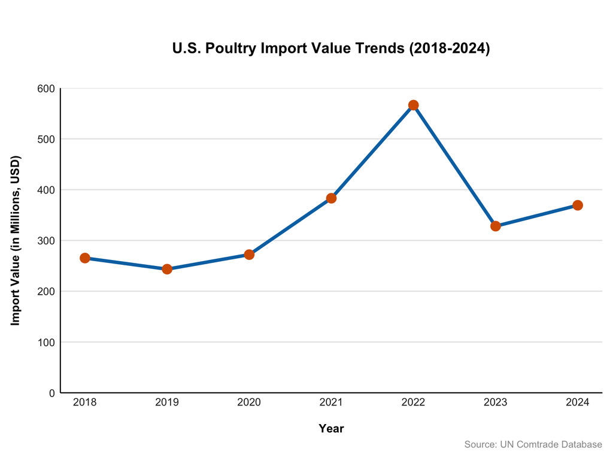

```r
# filter data for import trend between 2018-2024
import_trend <- poultry_data %>%
  filter(flow_desc == "Import",
         ref_year >= 2018,
         ref_year <= 2024) %>%
  group_by(ref_year) %>%
  summarize(total_import_value = sum(primary_value, na.rm = TRUE))

#plot
ggplot(data = import_trend,
       mapping = aes(x = ref_year,
                     y = total_import_value / 1000000)) +   # converting to Million
  geom_line(color = "#0072B2", linewidth = 1.5) +
  geom_point(color = "#D55E00", size = 4, shape = 19) +
  scale_x_continuous(breaks = 2018:2024) +
  scale_y_continuous(limits = c(0, 600),
                     breaks = seq(0, 600, 100),
                     expand = c(0, 0)) +
  labs(title = "U.S. Poultry Import Value Trends (2018-2024)",
       x = "Year",
       y = "Import Value (in Millions, USD)",
       caption = "Source: UN Comtrade Database") +
  theme_minimal() +
  theme(plot.title = element_text(face = "bold",
                                   size = 14,
                                   hjust = 0.5,
                                   color = "black",
                                   margin = margin(b = 30)),
        axis.title.y = element_text(face = "bold",
                                     size = 11,
                                     color = "black",
                                     margin = margin(r = 15)),
        axis.title.x = element_text(face = "bold",
                                    size = 11,
                                    color = "black",
                                    margin = margin(t = 15)),
        axis.text = element_text(size = 10, color = "gray15"),
        axis.line = element_line(color = "black", linewidth = 0.5),
        plot.margin = margin(t = 40, r = 10, b = 10, l = 10),
        panel.grid.minor = element_blank(),
        panel.grid.major.x = element_blank(),
        panel.grid.major.y = element_line(color = "gray90"),
        plot.caption = element_text(size = 9,
                                     color = "gray60",
                                     hjust = 1))
```

The line graph shows that USA poultry import values remained relatively stable between $200 million to $300 million USD from 2018 to 2020. Then, there was a sharp increase in import in 2021 and 2022 crossing over approximately $550 million USD. After that, import values declined in 2023-2024 to below $400 million USD.

## Exports:

#### 7. How many distinct countries were there (based on given data), to where US was exporting the poultry products?

```r
# export countries
export_countries <- poultry_data %>%
  filter(flow_desc == "Export") %>%
  distinct(partner_desc) %>%
  nrow()

print(export_countries)
```

```
[1] 188
```

Based on the given data, USA was exporting the poultry products to **188 countries**.

#### 8. What are the minimum, maximum trade values for exports? Mention the country, year and its respective value.

```r
# minimum and maximum export values
min_max_export <- bind_rows(
  poultry_data %>%
    filter(flow_desc == "Export") %>%
    arrange(primary_value) %>%
    slice(1) %>%
    mutate(Type = "Minimum"),
  poultry_data %>%
    filter(flow_desc == "Export") %>%
    arrange(desc(primary_value)) %>%
    slice(1) %>%
    mutate(Type = "Maximum")
) %>%
  mutate(`Value (USD)` = format(primary_value, big.mark = ",")) %>%
  select(Type,
         Country = partner_desc,
         Year = ref_year,
         `Value (USD)`)

knitr::kable(min_max_export,
             align = c("l", "l", "c", "r"),
             caption = "Minimum and Maximum Export Values")
```

Minimum and Maximum Export Values

| Type | Country | Year | Value (USD) |
| --- | --- | --- | --- |
| Minimum | Czechia | 2018 | 2,900 |
| Maximum | Mexico | 2024 | 1,172,550,687 |

According to the report, the **minimum** export trade value was $2,900 USD in 2018 with **Czechia**, and the **maximum** was 1.17 billion USD in 2024 with **Mexico**.

#### 9. Identify the top 5 countries to which the USA exported the most (qty) in the years 2018 and 2024. List the countries and their corresponding export values.

```r
# top 5 exports for 2018
top5_export_2018 <- poultry_data %>%
  filter(flow_desc == "Export", ref_year == 2018) %>%
  arrange(desc(qty_Mg)) %>%
  slice(1:5) %>%
  mutate(qty_Mg = round(qty_Mg, 2)) %>%
  select(Country = partner_desc,
         `Qty (Mg)` = qty_Mg,
         `Value (USD)` = primary_value)

# top 5 imports for 2024
top5_export_2024 <- poultry_data %>%
  filter(flow_desc == "Export", ref_year == 2024) %>%
  arrange(desc(qty_Mg)) %>%
  slice(1:5) %>%
  mutate(qty_Mg = round(qty_Mg, 2)) %>%
  select(Country = partner_desc,
         `Qty (Mg)` = qty_Mg,
         `Value (USD)` = primary_value)

# tables

knitr::kable(top5_export_2018,
             format.args = list(big.mark = ","),
             align = c("l", "r", "r"),
             caption = "Top 5 Export Countries by Quantity in 2018")
```

Top 5 Export Countries by Quantity in 2018

| Country | Qty (Mg) | Value (USD) |
| --- | --- | --- |
| Mexico | 792,813.1 | 763,541,266 |
| China, Hong Kong SAR | 291,713.1 | 412,669,749 |
| Angola | 209,389.4 | 183,671,360 |
| Other Asia, nes | 202,492.7 | 188,024,792 |
| Cuba | 195,235.0 | 154,537,803 |

```r
knitr::kable(top5_export_2024,
             format.args = list(big.mark = ","),
             align = c("l", "r", "r"),
             caption = "Top 5 Export Countries by Quantity in 2024")
```

Top 5 Export Countries by Quantity in 2024

| Country | Qty (Mg) | Value (USD) |
| --- | --- | --- |
| Mexico | 852,904.0 | 1,172,550,687 |
| Cuba | 239,643.2 | 298,231,173 |
| Other Asia, nes | 210,048.6 | 261,812,562 |
| Philippines | 163,084.0 | 187,724,475 |
| Canada | 148,189.1 | 403,487,221 |

Based on the export trade value with top 5 countries between 2018 and 2024, Mexico remained as a consistent export partner along with Cuba and other Asian territory (nes).

#### 10. Calculate the total export value for the USA from each country. Which country had the highest total import value **from** US, and what was that value?

```r
# total export value by country
total_export_by_country <- poultry_data %>%
  filter(flow_desc == "Export") %>%
  group_by(partner_desc) %>%
  summarize(total_export_value = sum(primary_value, na.rm = TRUE)) %>%
  arrange(desc(total_export_value)) %>%
  mutate(S.N. = row_number(),
         total_export_value = format(total_export_value, big.mark = ",")) %>%
  select(S.N.,
         Country = partner_desc,
         `Total Export Value (USD)` = total_export_value)

knitr::kable(head(total_export_by_country, 10),
             align = c("c", "l", "r"),
             caption = "Top 10 Countries by Total Export Value to USA")
```

| S.N. | Country | Total Export Value (USD) |
| --- | --- | --- |
| 1 | Mexico | 6,823,047,519 |
| 2 | China | 3,813,940,305 |
| 3 | Canada | 2,227,869,347 |
| 4 | Other Asia, nes | 1,674,974,582 |
| 5 | Cuba | 1,635,093,053 |
| 6 | China, Hong Kong SAR | 1,143,876,295 |
| 7 | Angola | 1,028,925,256 |
| 8 | Guatemala | 1,004,824,791 |
| 9 | Philippines | 978,700,870 |
| 10 | Viet Nam | 869,091,874 |

**Mexico** had the highest total import of $6.82 billion USD from the USA over the period.

#### 11. Calculate the total export value for the USA in each year from 2018 to 2025. Which year had the highest total export value, and what was that value?

```r
# total yearly export
total_exports_by_year <- poultry_data %>%
  filter(flow_desc == "Export") %>%
  group_by(ref_year) %>%
  summarize(total_export_value = sum(primary_value, na.rm = TRUE)) %>%
  arrange(ref_year) %>%
  mutate(total_export_value = format(total_export_value, big.mark = ",")) %>%
  select(Year = ref_year,
         `Total Export Value (USD)` = total_export_value)

knitr::kable(total_exports_by_year,
             align = c("c", "r"),
             caption = "Total Export Value by Year")
```

Total Export Value by Year

| Year | Total Export Value (USD) |
| --- | --- |
| 2018 | 3,628,826,731 |
| 2019 | 3,749,261,464 |
| 2020 | 3,837,181,558 |
| 2021 | 4,772,894,502 |
| 2022 | 5,401,343,250 |
| 2023 | 4,886,389,111 |
| 2024 | 4,766,297,796 |

USA had the **highest** total export value of **$5.40 billions USD** in the year 2022 and the **lowest** as **$3.63 billion USD** in the year 2018.

#### 12. Plot a line graph showing the total annual export value for the USA from 2018 to 2024. Describe any noticeable trends or patterns (e.g., increases, decreases, or fluctuations) in the graph. Create a publication ready plot.

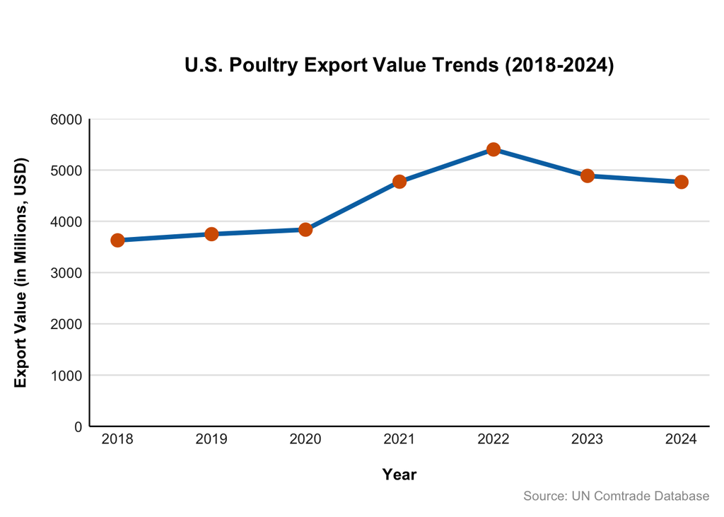

```r
#| fig-margin: true
#| fig-width: 8
#| fig-height: 6

# Filter data for export trend between 2018-2024
export_trend <- poultry_data %>%
  filter(flow_desc == "Export",
         ref_year >= 2018,
         ref_year <= 2024) %>%
  group_by(ref_year) %>%
  summarize(total_export_value = sum(primary_value, na.rm = TRUE))

# Plot
ggplot(data = export_trend,
       mapping = aes(x = ref_year,
                     y = total_export_value / 1000000)) +   # converting to Million
  geom_line(color = "#0072B2", linewidth = 1.5) +
  geom_point(color = "#D55E00", size = 4, shape = 19) +
  scale_x_continuous(breaks = 2018:2024) +
  scale_y_continuous(limits = c(0, 6000),
                     breaks = seq(0, 6000, 1000),
                     expand = c(0, 0)) +
  labs(title = "U.S. Poultry Export Value Trends (2018-2024)",
       x = "Year",
       y = "Export Value (in Millions, USD)",
       caption = "Source: UN Comtrade Database") +
  theme_minimal() +
  theme(plot.title = element_text(face = "bold",
                                   size = 14,
                                   hjust = 0.5,
                                   color = "black",
                                   margin = margin(b = 30)),
        axis.title.y = element_text(face = "bold",
                                     size = 11,
                                     color = "black",
                                     margin = margin(r = 15)),
        axis.title.x = element_text(face = "bold",
                                    size = 11,
                                    color = "black",
                                    margin = margin(t = 15)),
        axis.text = element_text(size = 10, color = "gray15"),
        axis.line = element_line(color = "black", linewidth = 0.5),
        plot.margin = margin(t = 40, r = 10, b = 10, l = 10),
        panel.grid.minor = element_blank(),
        panel.grid.major.x = element_blank(),
        panel.grid.major.y = element_line(color = "gray90"),
        plot.caption = element_text(size = 9,
                                     color = "gray60",
                                     hjust = 1))
```

USA poultry export values remained relatively stable between $3,000 to $4,000 million USD from 2018 to 2020. There was a noticeable increase in export in 2021 and 2022 crossing over $5,200 million USD. In following years, 2023 and 2024, export became stagnant just below 5,000 million USD margin.

## Imports - Exports Comparision:

#### 13. Does the U.S. behave more as a net importer or net exporter for this commodity? Explore it:

- Based on total value US imports and exports.
- Based on number of countries US imports and exports
- Based on each year’s import export value.

```r
# Total value comparison
total_trade <- poultry_data %>%
  group_by(flow_desc) %>%
  summarize(total_value = sum(primary_value, na.rm = TRUE)) %>%
  mutate(total_value = format(total_value, big.mark = ",")) %>%
  select(`Trade Flow` = flow_desc,
         `Total Value (USD)` = total_value)

knitr::kable(total_trade,
             align = c("l", "r"),
             caption = "Total Trade Value by Flow")
```

Total Trade Value by Flow

| Trade Flow | Total Value (USD) |
| --- | --- |
| Export | 31,042,194,412 |
| Import | 2,427,597,118 |

```r
# Number of countries comparison
country_count <- poultry_data %>%
  group_by(flow_desc) %>%
  summarize(num_countries = n_distinct(partner_desc)) %>%
  select(`Trade Flow` = flow_desc,
         `Number of Countries` = num_countries)

knitr::kable(country_count,
             align = c("l", "c"),
             caption = "Number of Trading Partner Countries")
```

Number of Trading Partner Countries

| Trade Flow | Number of Countries |
| --- | --- |
| Export | 188 |
| Import | 7 |

```r
# Yearly comparison
yearly_trade <- poultry_data %>%
  group_by(ref_year, flow_desc) %>%
  summarize(total_value = sum(primary_value, na.rm = TRUE), .groups = "drop") %>%
  pivot_wider(names_from = flow_desc, values_from = total_value) %>%
  mutate(net_position = Export - Import,
         trade_status = ifelse(net_position > 0, "Net Exporter", "Net Importer"),
         Export = format(Export, big.mark = ","),
         Import = format(Import, big.mark = ","),
         net_position = format(net_position, big.mark = ",")) %>%
  select(Year = ref_year,
         `Export (USD)` = Export,
         `Import (USD)` = Import,
         `Net Position (USD)` = net_position,
         `Trade Status` = trade_status)

knitr::kable(yearly_trade,
             align = c("c", "r", "r", "r", "l"),
             caption = "Yearly Trade Balance")
```

Yearly Trade Balance

| Year | Export (USD) | Import (USD) | Net Position (USD) | Trade Status |
| --- | --- | --- | --- | --- |
| 2018 | 3,628,826,731 | 265,311,797 | 3,363,514,934 | Net Exporter |
| 2019 | 3,749,261,464 | 243,440,897 | 3,505,820,567 | Net Exporter |
| 2020 | 3,837,181,558 | 272,062,857 | 3,565,118,701 | Net Exporter |
| 2021 | 4,772,894,502 | 383,046,235 | 4,389,848,267 | Net Exporter |
| 2022 | 5,401,343,250 | 566,412,591 | 4,834,930,659 | Net Exporter |
| 2023 | 4,886,389,111 | 328,085,936 | 4,558,303,175 | Net Exporter |
| 2024 | 4,766,297,796 | 369,236,805 | 4,397,060,991 | Net Exporter |

Based on total trade value flows, the USA **exported** poultry products worth **$31.04 billion USD** and **imported** products worth **$2.43 billion USD**. In the meantime, USA **exported to 188 countries** and **imported from just 7 countries**. Apart from this, USA had more net export than import every year between 2018 to 2024. So, the **USA behaves as a net exporter** of poultry products.

#### 14. Are the main import partners also major export destinations? Explore it based on the total import export value by countries.

```r
# top import partners
top_import_partners <- poultry_data %>%
  filter(flow_desc == "Import") %>%
  group_by(partner_desc) %>%
  summarize(total_import = sum(primary_value, na.rm = TRUE)) %>%
  arrange(desc(total_import)) %>%
  slice(1:20) %>%
  mutate(total_import = format(total_import, big.mark = ",")) %>%
  select(Country = partner_desc,
         `Total Import Value (USD)` = total_import)

knitr::kable(top_import_partners,
             align = c("l", "r"),
             caption = "Top Import Partners")
```

Top Import Partners

| Country | Total Import Value (USD) |
| --- | --- |
| Chile | 1,532,686,723 |
| Canada | 877,439,908 |
| Israel | 13,042,397 |
| Mexico | 4,111,455 |
| Germany | 206,221 |
| China | 106,106 |
| Poland | 4,308 |

```r
# top export destinations
top_export_partners <- poultry_data %>%
  filter(flow_desc == "Export") %>%
  group_by(partner_desc) %>%
  summarize(total_export = sum(primary_value, na.rm = TRUE)) %>%
  arrange(desc(total_export)) %>%
  slice(1:20) %>%
  mutate(total_export = format(total_export, big.mark = ",")) %>%
  select(Country = partner_desc,
         `Total Export Value (USD)` = total_export)

knitr::kable(top_export_partners,
             align = c("l", "r"),
             caption = "Top Export Destinations")
```

Top Export Destinations

| Country | Total Export Value (USD) |
| --- | --- |
| Mexico | 6,823,047,519 |
| China | 3,813,940,305 |
| Canada | 2,227,869,347 |
| Other Asia, nes | 1,674,974,582 |
| Cuba | 1,635,093,053 |
| China, Hong Kong SAR | 1,143,876,295 |
| Angola | 1,028,925,256 |
| Guatemala | 1,004,824,791 |
| Philippines | 978,700,870 |
| Viet Nam | 869,091,874 |
| Colombia | 548,255,976 |
| Haiti | 526,832,156 |
| Dominican Rep. | 511,312,247 |
| Georgia | 454,709,855 |
| Ghana | 449,193,423 |
| South Africa | 442,875,023 |
| Congo | 408,612,516 |
| United Arab Emirates | 375,565,998 |
| Chile | 372,480,927 |
| Kazakhstan | 267,994,000 |

**Yes.** Based on total export and import values, some of the main import partners like Canada, Mexico, China and Chile are also the main export destinations.

#### 15. Can you calculate if US is in trade surplus or trade deficit for each year from 2018-2024?

```r
# Calculating trade balance
trade_balance <- poultry_data %>%
  filter(ref_year >= 2018, ref_year <= 2024) %>%
  group_by(ref_year, flow_desc) %>%
  summarize(total_value = sum(primary_value, na.rm = TRUE), .groups = "drop") %>%
  pivot_wider(names_from = flow_desc, values_from = total_value) %>%
  mutate(trade_balance = Export - Import,
         status = ifelse(trade_balance > 0, "Surplus", "Deficit"))

# Clean table
trade_balance_table <- trade_balance %>%
  mutate(Export = format(Export, big.mark = ","),
         Import = format(Import, big.mark = ","),
         trade_balance = format(trade_balance, big.mark = ",")) %>%
  select(Year = ref_year,
         `Export (USD)` = Export,
         `Import (USD)` = Import,
         `Trade Balance (USD)` = trade_balance,
         `Trade Status` = status)

knitr::kable(trade_balance_table,
             align = c("c", "r", "r", "r", "r"),
             caption = "U.S. Poultry Trade Balance (2018-2024)")
```

U.S. Poultry Trade Balance (2018-2024)

| Year | Export (USD) | Import (USD) | Trade Balance (USD) | Trade Status |
| --- | --- | --- | --- | --- |
| 2018 | 3,628,826,731 | 265,311,797 | 3,363,514,934 | Surplus |
| 2019 | 3,749,261,464 | 243,440,897 | 3,505,820,567 | Surplus |
| 2020 | 3,837,181,558 | 272,062,857 | 3,565,118,701 | Surplus |
| 2021 | 4,772,894,502 | 383,046,235 | 4,389,848,267 | Surplus |
| 2022 | 5,401,343,250 | 566,412,591 | 4,834,930,659 | Surplus |
| 2023 | 4,886,389,111 | 328,085,936 | 4,558,303,175 | Surplus |
| 2024 | 4,766,297,796 | 369,236,805 | 4,397,060,991 | Surplus |

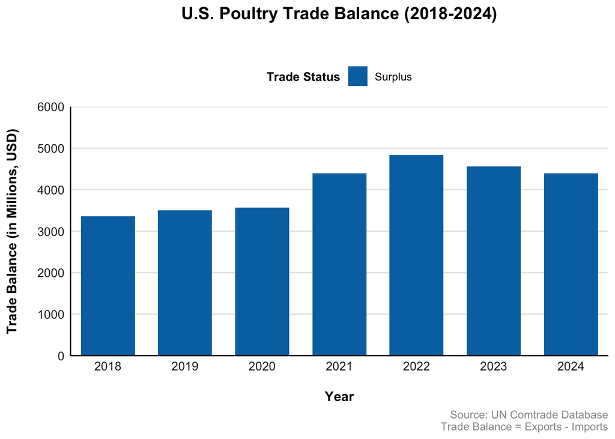

```r
# Visualization
ggplot(data = trade_balance,
       mapping = aes(x = ref_year, y = trade_balance / 1000000)) +
  geom_col(aes(fill = status), width = 0.7) +
  geom_hline(yintercept = 0, linetype = "dashed", color = "black", linewidth = 0.5) +
  scale_fill_manual(values = c("Surplus" = "#0072B2", "Deficit" = "#D55E00")) +
  scale_x_continuous(breaks = 2018:2024,
                     expand = expansion(mult = c(0.02, 0.02))) +
  scale_y_continuous(limits = c(0, 6000),
                     breaks = seq(0, 6000, 1000),
                     expand = c(0, 0)) +
  labs(title = "U.S. Poultry Trade Balance (2018-2024)",
       x = "Year",
       y = "Trade Balance (in Millions, USD)",
       fill = "Trade Status",
       caption = "Source: UN Comtrade Database\nTrade Balance = Exports - Imports") +
  theme_minimal() +
  theme(plot.title = element_text(face = "bold",
                                   size = 14,
                                   hjust = 0.5,
                                   color = "black",
                                   margin = margin(b = 30)),
        axis.title.y = element_text(face = "bold",
                                     size = 11,
                                     color = "black",
                                     margin = margin(r = 15)),
        axis.title.x = element_text(face = "bold",
                                    size = 11,
                                    color = "black",
                                    margin = margin(t = 15)),
        axis.text = element_text(size = 10, color = "gray15"),
        axis.line = element_line(color = "black", linewidth = 0.5),
        legend.position = "top",
        legend.title = element_text(face = "bold", size = 10),
        legend.text = element_text(size = 9),
        panel.grid.minor = element_blank(),
        panel.grid.major.x = element_blank(),
        panel.grid.major.y = element_line(color = "gray90"),
        plot.caption = element_text(size = 9,
                                     color = "gray60",
                                     hjust = 1))
```

USA maintained a **trade surplus** in poultry products for every year from 2018 to 2024. The surplus grew from approximately $3.36 billion USD in 2018 to approximately $4.40 billion in 2024 demonstrating the strong competitive position as a **net exporter** of poultry products.

# Submitting your work

Once you have developed all the code and answers, make sure to Render this quarto file.

**Notes on rendering**:

- Make sure to render your work and inspect how the final html look like.
- If it does not look professional for whatever reason, then fix the issue, re-render it, recheck.
- Only send me your work once your html file looks professional.
- Some potential issues you may encounter and how to fix them:
  - Some times your code may be creating a table output that is waaay too long and cumbersome to scroll through when rendered. If this is the case, make it more professional looking by using the `head()` function to only print the first handful of rows (instead of thousands of rows).
  - **DO NOT** delete the file’s heading levels (# and ##). They set up the proper heading 1 and 2 levels, and I use them to guide my grading.
  - There’s a total of **15 questions**. If you mess around with the heading levels and you get a different number of questions on the rendered version, fix it.
  - If a given chunk is also outputting warnings or messages, inhibit this behavior by changing the chunk options `message` and `warning` to `FALSE` (I’ll demo this in a moment).
  - If, after rendered, 2 lines of text are connected and you wish to “break line” between them, add 2 extra spaces after the first one (I’ll demo this in a moment).

After rendering, an .html file will be created on your `code` folder.

Rename this file to `03_assignment_LASTNAME.html`.

For ex., `03_assignment_Bastos.html`.

Submit the html file on eLC by Wed Feb 4th 11:59 pm, **one week** from today.